# Programming & Wrangling

## the dplyr package

It provides a consistent and simple interface to do common data manipulation tasks

## the dplyr package

`dplyr` is very consistent

it assumes that you are starting with a dataframe, doing something to that dataframe, and finishing with a different dataframe.

Many of the base R functions operate on atomic vectors, which makes it more complicated to apply them to dataframes.)

`dplyr` introduces a series of simple 'verbs' that describe many common data manipulation tasks.

## Challenge

We will use a dataset on student loans in public and private universities.

Read in this dataset called DMV_2014_Q3_Undergrad_DirectLoans.txt and save it to a variable called `loans`.

## The basic dplyr verbs

There are a few basic functions in `dplyr`

The first argument to these functions is always the dataframe that you want to manipulate.

Within these function calls, you can refer to the names of columns in the dataframe without quotation marks and without the usual `$` syntax.

```r
library(dplyr)
```

## `filter()`

This function selects a subset of rows meeting some criterion. Note that the result is a dataframe.

```r
filter(loans, School=="GEORGE WASHINGTON UNIVERSITY")
```

```
##                         School State      School_Type SubsidizedDL
## 1 GEORGE WASHINGTON UNIVERSITY    DC PrivateNonprofit      7463145
##   UNSubsidizedDL
## 1        5913027
```

## `arrange()`

This function is like the "sort" function in MS Excel. You simply provide a list of column names to sort by:

```r
arrange(loans, State, SubsidizedDL)
```

```
##                                                                   School
## 1                                 NATIONAL CONSERVATORY OF DRAMATIC ARTS
## 2                                             TECHNICAL LEARNING CENTERS
## 3                                               BENNETT CAREER INSTITUTE
## 4                                                        RADIANS COLLEGE
## 5                                     CORCORAN COLLEGE OF ART AND DESIGN
## 6                                             CAREER TECHNICAL INSTITUTE
## 7                                                   GALLAUDET UNIVERSITY
## 8                                                        TRINITY COLLEGE
## 9                                         CATHOLIC UNIVERSITY OF AMERICA
## 10                                                 GEORGETOWN UNIVERSITY
## 11                                UNIVERSITY OF THE DISTRICT OF COLUMBIA
## 12                                                   AMERICAN UNIVERSITY
## 13                                          GEORGE WASHINGTON UNIVERSITY
## 14                                                     HOWARD UNIVERSITY
```

[output cut: 407 more lines]

```r
arrange(loans, State, desc(SubsidizedDL))
```

```
##                                                                   School
## 1                                                     STRAYER UNIVERSITY
## 2                                                      HOWARD UNIVERSITY
## 3                                           GEORGE WASHINGTON UNIVERSITY
## 4                                                    AMERICAN UNIVERSITY
## 5                                 UNIVERSITY OF THE DISTRICT OF COLUMBIA
## 6                                                  GEORGETOWN UNIVERSITY
## 7                                         CATHOLIC UNIVERSITY OF AMERICA
## 8                                                        TRINITY COLLEGE
## 9                                                   GALLAUDET UNIVERSITY
## 10                                            CAREER TECHNICAL INSTITUTE
## 11                                    CORCORAN COLLEGE OF ART AND DESIGN
## 12                                                       RADIANS COLLEGE
## 13                                              BENNETT CAREER INSTITUTE
## 14                                            TECHNICAL LEARNING CENTERS
```

[output cut: 407 more lines]

## `select()`

This function pulls out colums of interest. You can select ranges of columns using the `:` operator syntax. (Note: usually this only works with numeric data, but this is a special usage defined in the `dplyr` package)

```r
select(loans, State, SubsidizedDL)
```

```
##     State SubsidizedDL
## 1      DC      6213538
## 2      DC      3619502
## 3      DC      3850272
## 4      DC       679602
## 5      DC      7463145
## 6      DC      3824260
## 7      DC      9414766
## 8      DC     22490396
## 9      DC      2522961
## 10     DC           NA
## 11     DC       356355
## 12     DC           NA
## 13     DC        40812
## 14     DC       416911
```

[output cut: 196 more lines]

```r
select(loans, -State, -SubsidizedDL)
```

```
##                                                                   School
## 1                                                    AMERICAN UNIVERSITY
## 2                                         CATHOLIC UNIVERSITY OF AMERICA
## 3                                 UNIVERSITY OF THE DISTRICT OF COLUMBIA
## 4                                                   GALLAUDET UNIVERSITY
## 5                                           GEORGE WASHINGTON UNIVERSITY
## 6                                                  GEORGETOWN UNIVERSITY
## 7                                                      HOWARD UNIVERSITY
## 8                                                     STRAYER UNIVERSITY
## 9                                                        TRINITY COLLEGE
## 10                                           WESLEY THEOLOGICAL SEMINARY
## 11                                    CORCORAN COLLEGE OF ART AND DESIGN
## 12                                            DOMINICAN HOUSE OF STUDIES
## 13                                NATIONAL CONSERVATORY OF DRAMATIC ARTS
## 14                                            CAREER TECHNICAL INSTITUTE
```

[output cut: 407 more lines]

```r
select(loans, State:SubsidizedDL)
```

```
##     State      School_Type SubsidizedDL
## 1      DC PrivateNonprofit      6213538
## 2      DC PrivateNonprofit      3619502
## 3      DC           Public      3850272
## 4      DC PrivateNonprofit       679602
## 5      DC PrivateNonprofit      7463145
## 6      DC PrivateNonprofit      3824260
## 7      DC PrivateNonprofit      9414766
## 8      DC      Proprietary     22490396
## 9      DC PrivateNonprofit      2522961
## 10     DC PrivateNonprofit           NA
## 11     DC PrivateNonprofit       356355
## 12     DC PrivateNonprofit           NA
## 13     DC PrivateNonprofit        40812
## 14     DC      Proprietary       416911
```

[output cut: 196 more lines]

## `distinct()`

This function extracts the distinct rows. It is most useful when combined with select

```r
distinct(loans)
```

```
##                                                                   School
## 1                                                    AMERICAN UNIVERSITY
## 2                                         CATHOLIC UNIVERSITY OF AMERICA
## 3                                 UNIVERSITY OF THE DISTRICT OF COLUMBIA
## 4                                                   GALLAUDET UNIVERSITY
## 5                                           GEORGE WASHINGTON UNIVERSITY
## 6                                                  GEORGETOWN UNIVERSITY
## 7                                                      HOWARD UNIVERSITY
## 8                                                     STRAYER UNIVERSITY
## 9                                                        TRINITY COLLEGE
## 10                                           WESLEY THEOLOGICAL SEMINARY
## 11                                    CORCORAN COLLEGE OF ART AND DESIGN
## 12                                            DOMINICAN HOUSE OF STUDIES
## 13                                NATIONAL CONSERVATORY OF DRAMATIC ARTS
## 14                                            CAREER TECHNICAL INSTITUTE
```

[output cut: 407 more lines]

```r
distinct(select(loans, State, School_Type))
```

```
##   State      School_Type
## 1    DC PrivateNonprofit
## 2    DC           Public
## 3    DC      Proprietary
## 4    MD PrivateNonprofit
## 5    MD           Public
## 6    MD      Proprietary
## 7    VA PrivateNonprofit
## 8    VA           Public
## 9    VA      Proprietary
```

## `mutate()`

Adds new columns that are some function of existing columns

```r
mutate(loans, Total_Loans = SubsidizedDL + UNSubsidizedDL)
```

```
##                                                                   School
## 1                                                    AMERICAN UNIVERSITY
## 2                                         CATHOLIC UNIVERSITY OF AMERICA
## 3                                 UNIVERSITY OF THE DISTRICT OF COLUMBIA
## 4                                                   GALLAUDET UNIVERSITY
## 5                                           GEORGE WASHINGTON UNIVERSITY
## 6                                                  GEORGETOWN UNIVERSITY
## 7                                                      HOWARD UNIVERSITY
## 8                                                     STRAYER UNIVERSITY
## 9                                                        TRINITY COLLEGE
## 10                                           WESLEY THEOLOGICAL SEMINARY
## 11                                    CORCORAN COLLEGE OF ART AND DESIGN
## 12                                            DOMINICAN HOUSE OF STUDIES
## 13                                NATIONAL CONSERVATORY OF DRAMATIC ARTS
## 14                                            CAREER TECHNICAL INSTITUTE
```

[output cut: 407 more lines]

## `rowwise()`

Mutate works as expected when you want to manupulate whole columns at once, but sometimes you want to do something on a row-by-row basis.

For example: this code doesn't work as you might expect

```r
myDF <- data.frame(x=c(1,2,3), y=c(10, 11, 12))
mutate(myDF, sum=sum(x, y))
```

```
##   x  y sum
## 1 1 10  39
## 2 2 11  39
## 3 3 12  39
```

## `rowwise()`

But this code computes the sum on a row-by-row basis, as you might expect

```r
myDF <- data.frame(x=c(1,2,3), y=c(10, 11, 12))
mutate(rowwise(myDF), sum=sum(x, y))
```

```
## Source: local data frame [3 x 3]
## Groups: <by row>
##
## # A tibble: 3 x 3
##       x     y   sum
##   <dbl> <dbl> <dbl>
## 1     1    10    11
## 2     2    11    13
## 3     3    12    15
```

## `summarise()`

Summarizes data into a single row. This may seem not that useful, but it will become useful when we start grouping data.

```r
summarise(loans, meanSubDL = mean(SubsidizedDL, na.rm=TRUE))
```

```
##   meanSubDL
## 1   2607474
```

## Grouping Data

These functions above get really powerful when you start grouping data based on factors in your dataset.

## `group_by()`

```r
groupedLoans <- group_by(loans, State)
summarise(groupedLoans, meanSubDL = mean(SubsidizedDL, na.rm=TRUE))
```

```
## # A tibble: 3 x 2
##   State meanSubDL
##   <fct>     <dbl>
## 1 DC     4094947.
## 2 MD     2132025.
## 3 VA     2730055.
```

## Chaining operations

`dplyr` also provides a way of chaining together commplicated operations with the `%>%` operator.

This prevents having to save intermediate steps, or to have a complicated series of nested functions.

Note that the resulting dataframe from each step is passed as the first argument to the next function in the chain.

## Chaining operations

```r
group_by(loans, School_Type) %>%
  mutate(Total_Loans = SubsidizedDL + UNSubsidizedDL) %>%
  select(-State) %>%
  summarise(mean_total_loans = mean(Total_Loans, na.rm=TRUE))
```

```
## # A tibble: 3 x 2
##   School_Type      mean_total_loans
##   <fct>                       <dbl>
## 1 PrivateNonprofit         5115076.
## 2 Proprietary              1796278.
## 3 Public                  10315783.
```

## Chaining works with non-`dplyr()` functions too

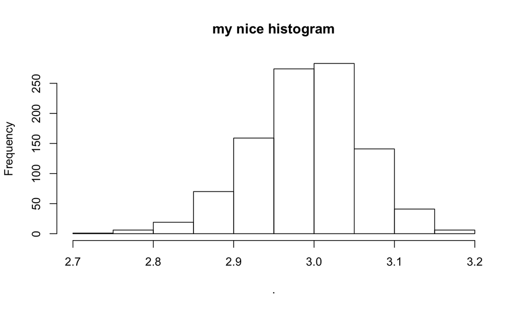

```r
#chained syntax
rnorm(1000, mean=20, sd=1.4) %>% log %>% hist(main="my nice histogram")
```

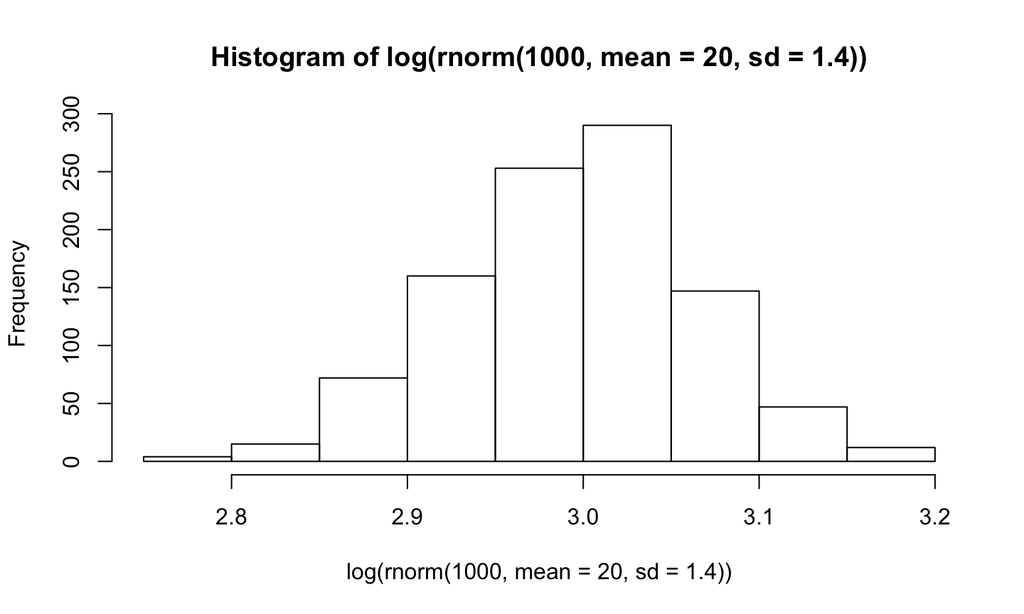

```r
#compare with nested function calls

hist(log(rnorm(1000, mean=20, sd=1.4)))
```

## `do()`

do anything to grouped data

```r
linearModels <- loans %>% group_by(State) %>%
  do(regression=lm(UNSubsidizedDL~SubsidizedDL, data=.))
linearModels
```

```
## Source: local data frame [3 x 2]
## Groups: <by row>
##
## # A tibble: 3 x 2
##   State regression
## * <fct> <list>
## 1 DC    <S3: lm>
## 2 MD    <S3: lm>
## 3 VA    <S3: lm>
```

## `do()`

```r
linearModels <- loans %>% group_by(State) %>%
  do(regression=lm(UNSubsidizedDL~SubsidizedDL, data=.))
linearModels
```

[output not shown]

```r
linearModels %>%
  summarize(sum=summary(regression)$r.squared)
```

```
## # A tibble: 3 x 1
##     sum
##   <dbl>
## 1 0.939
## 2 0.958
## 3 0.983
```

## Challenge

Using the `diamonds` dataset that is built in to the `ggplot2` package:

- calculate the mean price of diamonds for each of the different clarity ratings
- create a new column called `volume` that is the product of x, y and z
- plot `volume` against `carat`

## More info

A more complete introduction is available in the [`dplyr` vignette](http://cran.rstudio.com/web/packages/dplyr/vignettes/introduction.html)

More info on `magrittr` [can be found here](http://cran.r-project.org/web/packages/magrittr/vignettes/magrittr.html).

## Bonus content: programming in R

R is a programming language, which means that it gives you all the tools you need to automate repetitive tasks. There are three (or more) main ways to do this:

- `for` loops
- the `lapply()` function
- the `dplyr` package

## for loops

`for` loops will be familiar if you have ever used any other programming languages. The basic structure looks like this:

```r
vector <- 1:10
for(i in vector){
  #do something with i
}
```

## for loops

Here is a (slightly) more complicated example.

```r
myVector <- 1:10
for(counter in myVector){
  result <- paste("counter ^ 2 = ", counter^2)
  print(result)
}
```

```
## [1] "counter ^ 2 =  1"
## [1] "counter ^ 2 =  4"
## [1] "counter ^ 2 =  9"
## [1] "counter ^ 2 =  16"
## [1] "counter ^ 2 =  25"
## [1] "counter ^ 2 =  36"
## [1] "counter ^ 2 =  49"
## [1] "counter ^ 2 =  64"
## [1] "counter ^ 2 =  81"
## [1] "counter ^ 2 =  100"
```

## getting stuff out of a loop

- Create a results vector in advance that is the same length as the vector we are looping over
- Then save the results each time in the appropriate slot.

```r
myVector <- runif(5, min = 1, max=10); myVector
```

```
## [1] 3.075945 1.313335 9.683253 7.920894 8.643216
```

```r
results <- numeric(5)
for(each in 1:length(myVector)){
  results[each] <- paste(myVector[each], "^ 2 = ", myVector[each]^2)
}

results[3]
```

```
## [1] "9.68325309897773 ^ 2 =  93.7653905788618"
```

## `if` statements

- Often during a loop, you may want to do a test and do something different based on the results of the test.
- Imagine a vector of germination outcomes from a seed experiment.
- 0 indicates the seed did not germinate due to insect predatoin
- 1 indicates that it did not germinate but no insect predation occurrend
- 2 indicates that the seed germinated.

We can use the `if()` function to evaluate the outcome and provide context specific output.

```r
outcomes <- c(0,1,0,2,0,1,0,2,0,1,0,1,0,0)
for(trial in outcomes){
  if(trial == 2) print("Welcome to the world, plantling!")
  else print("RIP")
}
```

```
## [1] "RIP"
## [1] "RIP"
## [1] "RIP"
## [1] "Welcome to the world, plantling!"
## [1] "RIP"
## [1] "RIP"
## [1] "RIP"
## [1] "Welcome to the world, plantling!"
## [1] "RIP"
## [1] "RIP"
## [1] "RIP"
## [1] "RIP"
## [1] "RIP"
## [1] "RIP"
```

## Challenge

Write a `for` loop to examine the law of large numbers to illustrate how, as sample size increases, estimates of the mean of a population converge on the true value. Do this in the following steps:

- create a numeric results vector of length 2000
- loop over each integer `i` from 1 to 2000
- at each iteration use the `rnorm()` function to simulate a sample of size `i` from a population with a mean of 100 and standard deviation of 30.
- calculate the mean of this sample, and be sure to save these results to the appropriate place in the results vector
- finally, make a plot of the results with the integers 1 to 2000 on the x axis, and the corresponding value from the results vector on the y axis

## `lapply()`

The function `lapply()` is like a `for` loop, but is optimized and explicitly functional.

`lapply()` usually takes two arguments

- `X` which is a list or a vector to loop over
- `FUN` which is a function to apply to each element of `X`.

Thus, `FUN` must be able to accept any element of `X` as an argument.

```r
x <- c("dog","cat", "cucumber")
lapply(x, FUN=nchar)
```

```
## [[1]]
## [1] 3
##
## [[2]]
## [1] 3
##
## [[3]]
## [1] 8
```

## Writing your own functions

Functions are the best way to encapsulate code that you want to repeat again and again.

A function accepts **arguments** and **returns** a single (and only a single) object.

Variable names defined within a function only exist within the function (not within the global environment).

## Writing your own functions

```r
is.even <- function(number){
  if(number %% 2 == 0) {return("The number is even")}
  else {return("The number is not even")}
}

is.even(1233)
```

```
## [1] "The number is not even"
```

```r
is.even(1234)
```

```
## [1] "The number is even"
```

```r
is.even(-1.2)
```

```
## [1] "The number is not even"
```

## Lists

The "l" in `lapply()` stands for "list", because that's what you get as a result.

**lists can hold any type of data, not every element needs to be the same type.**

```r
myList <- list(firstOne=1, nextOne="too", lastOne=rnorm(10))
myList
```

```
## $firstOne
## [1] 1
##
## $nextOne
## [1] "too"
##
## $lastOne
##  [1]  0.84466722  0.08560900 -1.41884320  0.77558494  0.68531686
##  [6]  0.70119908  0.83377500  0.09936071  1.35451968  0.01123037
```

## often use double brackets `[[]]` to index a list

```r
myList[[3]]
```

```
##  [1]  0.84466722  0.08560900 -1.41884320  0.77558494  0.68531686
##  [6]  0.70119908  0.83377500  0.09936071  1.35451968  0.01123037
```

```r
myList[3]
```

```
## $lastOne
##  [1]  0.84466722  0.08560900 -1.41884320  0.77558494  0.68531686
##  [6]  0.70119908  0.83377500  0.09936071  1.35451968  0.01123037
```

For five marks….what is the difference?

## `[[]]` versus `[]`

[figure not shown]

## lists can (optionally) have named elements, that can be accessed using the `$` operator

```r
myList$nextOne
```

```
## [1] "too"
```

Where have you seen the `$` operator before?

What does this suggest about the relationship between list and dataframes?

## Lists are useful because of their flexibility.

We can store complex results from each iteration, and then come back to these results later.

```r
# note, we must accept an argument
# even if we don't do anything with this argument.
summarizeRandom <- function(n){
  sample <- rnorm(n)
  mySummary <- summary(sample)
  return(mySummary)
}

sampleSizes <- 100:200
myResults <- lapply(sampleSizes, FUN=summarizeRandom)
myResults[1:3]
```

```
## [[1]]
##    Min. 1st Qu.  Median    Mean 3rd Qu.    Max.
## -2.3479 -0.4256  0.1167  0.1403  0.6273  2.7357
##
## [[2]]
##      Min.   1st Qu.    Median      Mean   3rd Qu.      Max.
## -2.604340 -0.748220 -0.060102 -0.005322  0.574293  2.277051
##
## [[3]]
##      Min.   1st Qu.    Median      Mean   3rd Qu.      Max.
## -2.721854 -0.516782  0.025997  0.005697  0.629834  2.007507
```